# Data621-hw1

Joseph Elikishvili

February 26, 2018

## 2. Data Exploration

First we will load the data and review the dimentions of the dataset

```
## [1] 2276   17
```

So we have a total of 2276 records and 17 variables.

Lets Review the data

```
##  [1] "INDEX"            "TARGET_WINS"      "TEAM_BATTING_H"
##  [4] "TEAM_BATTING_2B"  "TEAM_BATTING_3B"  "TEAM_BATTING_HR"
##  [7] "TEAM_BATTING_BB"  "TEAM_BATTING_SO"  "TEAM_BASERUN_SB"
## [10] "TEAM_BASERUN_CS"  "TEAM_BATTING_HBP" "TEAM_PITCHING_H"
## [13] "TEAM_PITCHING_HR" "TEAM_PITCHING_BB" "TEAM_PITCHING_SO"
## [16] "TEAM_FIELDING_E"  "TEAM_FIELDING_DP"
```

It apears we have Index which is jus the index of the data and can be removed and we have our target variable Target_Wins and a total of 15 predictor variables we will be working with.

Next we will scan for missing values as those can affect the process

```
##            INDEX      TARGET_WINS   TEAM_BATTING_H  TEAM_BATTING_2B
##                0                0                0                0
##  TEAM_BATTING_3B  TEAM_BATTING_HR  TEAM_BATTING_BB  TEAM_BATTING_SO
##                0                0                0              102
##  TEAM_BASERUN_SB  TEAM_BASERUN_CS TEAM_BATTING_HBP  TEAM_PITCHING_H
##              131              772             2085                0
## TEAM_PITCHING_HR TEAM_PITCHING_BB TEAM_PITCHING_SO  TEAM_FIELDING_E
##                0                0              102                0
## TEAM_FIELDING_DP
##              286
```

We can see that we have a reasonable number of missing values ofr the most of the predictors with the exception if TEAM_BATTING_HBP ( 2085 ) and TEAM_BASERUN_CS ( 772). These is a significant number considering we have a total 2276 records. Once option is to remove teh 2 columns, but we will attempt to impute the missing data and see if it can stil be useful to us.

Next we will review the predictors given to us to better understand the data we are dealing with. The table gives us a basic overview of the data

|  | vars | n | mean | sd | median | trimmed | mad | min | max | range | skew | kurtosis | se |
| --- | --- | --- | --- | --- | --- | --- | --- | --- | --- | --- | --- | --- | --- |
| TARGET_WINS | 1 | 2276 | 80.79 | 15.75 | 82.0 | 81.31 | 14.83 | 0 | 146 | 146 | -0.40 | 1.03 | 0.33 |
| TEAM_BATTING_H | 2 | 2276 | 1469.27 | 144.59 | 1454.0 | 1459.04 | 114.16 | 891 | 2554 | 1663 | 1.57 | 7.28 | 3.03 |
| TEAM_BATTING_2B | 3 | 2276 | 241.25 | 46.80 | 238.0 | 240.40 | 47.44 | 69 | 458 | 389 | 0.22 | 0.01 | 0.98 |
| TEAM_BATTING_3B | 4 | 2276 | 55.25 | 27.94 | 47.0 | 52.18 | 23.72 | 0 | 223 | 223 | 1.11 | 1.50 | 0.59 |
| TEAM_BATTING_HR | 5 | 2276 | 99.61 | 60.55 | 102.0 | 97.39 | 78.58 | 0 | 264 | 264 | 0.19 | -0.96 | 1.27 |
| TEAM_BATTING_BB | 6 | 2276 | 501.56 | 122.67 | 512.0 | 512.18 | 94.89 | 0 | 878 | 878 | -1.03 | 2.18 | 2.57 |
| TEAM_BATTING_SO | 7 | 2174 | 735.61 | 248.53 | 750.0 | 742.31 | 284.66 | 0 | 1399 | 1399 | -0.30 | -0.32 | 5.33 |
| TEAM_BASERUN_SB | 8 | 2145 | 124.76 | 87.79 | 101.0 | 110.81 | 60.79 | 0 | 697 | 697 | 1.97 | 5.49 | 1.90 |
| TEAM_BASERUN_CS | 9 | 1504 | 52.80 | 22.96 | 49.0 | 50.36 | 17.79 | 0 | 201 | 201 | 1.98 | 7.62 | 0.59 |
| TEAM_BATTING_HBP | 10 | 191 | 59.36 | 12.97 | 58.0 | 58.86 | 11.86 | 29 | 95 | 66 | 0.32 | -0.11 | 0.94 |
| TEAM_PITCHING_H | 11 | 2276 | 1779.21 | 1406.84 | 1518.0 | 1555.90 | 174.95 | 1137 | 30132 | 28995 | 10.33 | 141.84 | 29.49 |
| TEAM_PITCHING_HR | 12 | 2276 | 105.70 | 61.30 | 107.0 | 103.16 | 74.13 | 0 | 343 | 343 | 0.29 | -0.60 | 1.28 |
| TEAM_PITCHING_BB | 13 | 2276 | 553.01 | 166.36 | 536.5 | 542.62 | 98.59 | 0 | 3645 | 3645 | 6.74 | 96.97 | 3.49 |
| TEAM_PITCHING_SO | 14 | 2174 | 817.73 | 553.09 | 813.5 | 796.93 | 257.23 | 0 | 19278 | 19278 | 22.17 | 671.19 | 11.86 |
| TEAM_FIELDING_E | 15 | 2276 | 246.48 | 227.77 | 159.0 | 193.44 | 62.27 | 65 | 1898 | 1833 | 2.99 | 10.97 | 4.77 |
| TEAM_FIELDING_DP | 16 | 1990 | 146.39 | 26.23 | 149.0 | 147.58 | 23.72 | 52 | 228 | 176 | -0.39 | 0.18 | 0.59 |

Next we will create a boxplot of each of the predictors to visualise the variablity of data

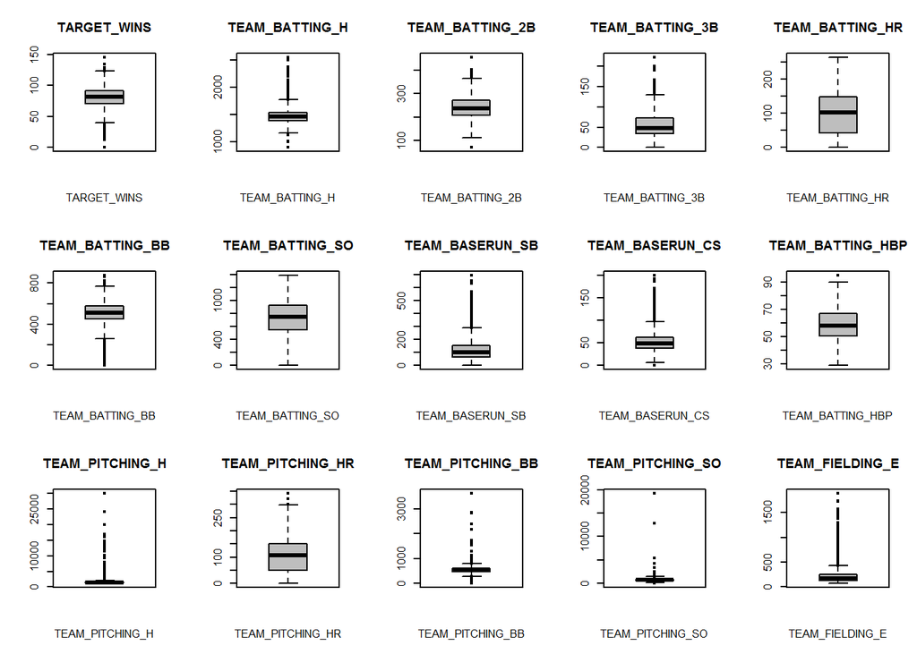

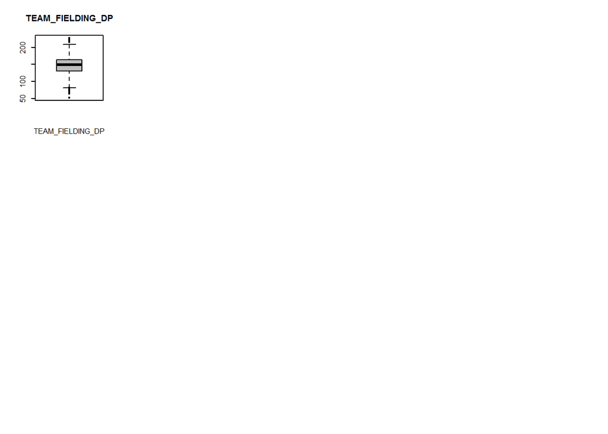

And finally we will review the histograms of the predictors to so the distribution and the skew.

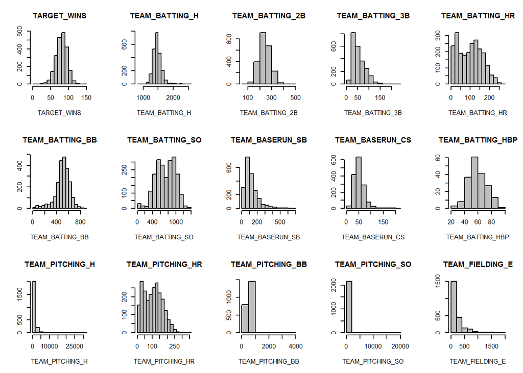

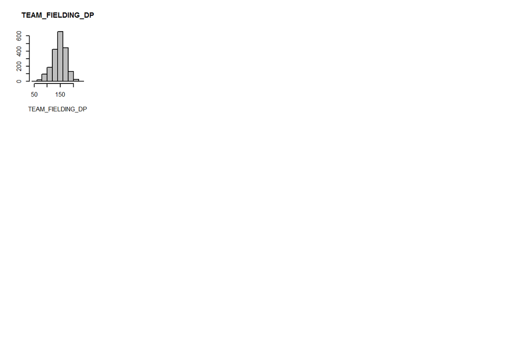

Next we will impute the missing data. Even though we have 2 predictors that have a lot of missing values, we will use them nevertheless and review the results. When we get to model selection, we will try a model with the predcistors that have been heavily imputed and compare to the model without them.

For imputation we will use missForest package which will choose the best suited method and will impute the mmissing data.

```
##   missForest iteration 1 in progress...done!
##   missForest iteration 2 in progress...done!
##   missForest iteration 3 in progress...done!
##   missForest iteration 4 in progress...done!
##   missForest iteration 5 in progress...done!
```

Lets review the imputed sata and scan for missing values.

```
##      TARGET_WINS   TEAM_BATTING_H  TEAM_BATTING_2B  TEAM_BATTING_3B
##                0                0                0                0
##  TEAM_BATTING_HR  TEAM_BATTING_BB  TEAM_BATTING_SO  TEAM_BASERUN_SB
##                0                0                0                0
##  TEAM_BASERUN_CS TEAM_BATTING_HBP  TEAM_PITCHING_H TEAM_PITCHING_HR
##                0                0                0                0
## TEAM_PITCHING_BB TEAM_PITCHING_SO  TEAM_FIELDING_E TEAM_FIELDING_DP
##                0                0                0                0
```

We no longer have any missing values and we are clear to proceed further.

Next we will create the correlation plot to visually identify correlated predictors.

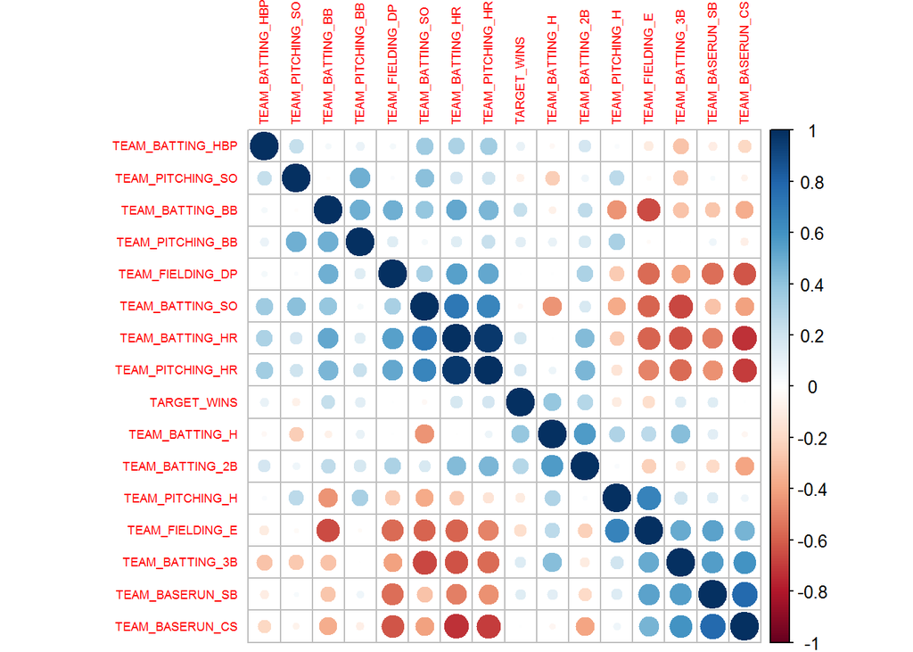

## 3. Data Preparation

Next we will use the Boxcos transformation to normalize the data. Once normalized, this will allow us to better work with the data. We will use Boxcox transformation to automatically select the appropriate transformation algorytm for our data

Next we will visualise data to see how well it was normalized after boxcox transformation and compare the results to the histograms before we applied the transformation.

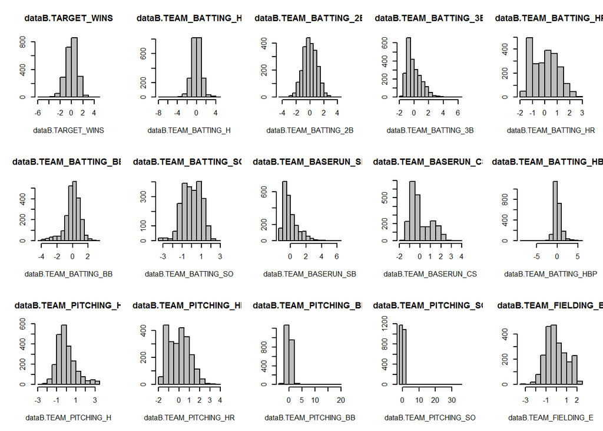

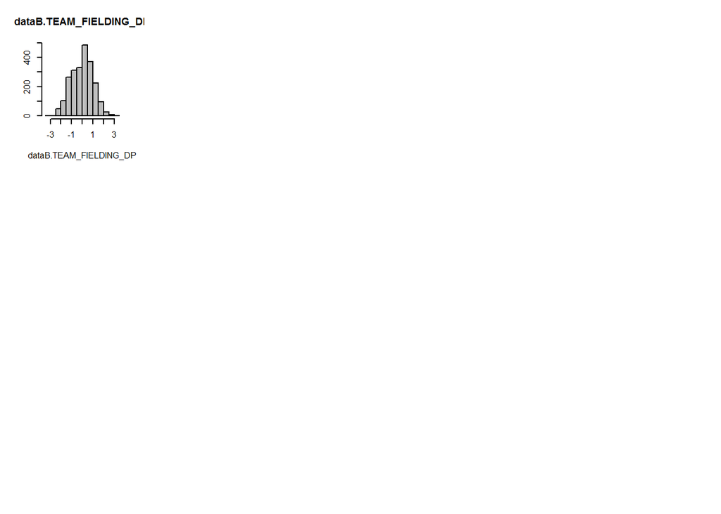

We can see that boxcox transformation has had a very positive result on the dataset and data is now normalized for the most part.

## 4. Build Model

First we will create a biasic model consisting of all imputed data

```
##
## Call:
## lm(formula = TARGET_WINS ~ ., data = datanorm)
##
## Residuals:
##     Min      1Q  Median      3Q     Max
## -3.9248 -0.5047  0.0001  0.5218  3.6150
##
## Coefficients:
##                    Estimate Std. Error t value Pr(>|t|)
## (Intercept)       1.784e-11  1.675e-02   0.000 1.000000
## TEAM_BATTING_H    4.305e-01  3.620e-02  11.893  < 2e-16 ***
## TEAM_BATTING_2B  -3.225e-02  2.707e-02  -1.191 0.233636
## TEAM_BATTING_3B   1.368e-01  3.019e-02   4.531 6.17e-06 ***
## TEAM_BATTING_HR  -1.967e-02  1.070e-01  -0.184 0.854117
## TEAM_BATTING_BB   2.430e-01  3.702e-02   6.563 6.54e-11 ***
## TEAM_BATTING_SO  -4.243e-01  4.219e-02 -10.055  < 2e-16 ***
## TEAM_BASERUN_SB   2.461e-01  3.110e-02   7.913 3.91e-15 ***
## TEAM_BASERUN_CS   1.555e-01  3.600e-02   4.318 1.64e-05 ***
## TEAM_BATTING_HBP  1.146e-01  1.868e-02   6.136 9.96e-10 ***
## TEAM_PITCHING_H  -2.227e-01  4.063e-02  -5.482 4.66e-08 ***
## TEAM_PITCHING_HR  2.898e-01  9.722e-02   2.981 0.002905 **
## TEAM_PITCHING_BB -1.304e-01  3.649e-02  -3.575 0.000358 ***
## TEAM_PITCHING_SO  1.705e-01  3.081e-02   5.534 3.50e-08 ***
## TEAM_FIELDING_E  -4.719e-01  3.794e-02 -12.435  < 2e-16 ***
## TEAM_FIELDING_DP -1.735e-01  2.360e-02  -7.352 2.71e-13 ***
## ---
## Signif. codes:  0 '***' 0.001 '**' 0.01 '*' 0.05 '.' 0.1 ' ' 1
##
## Residual standard error: 0.7993 on 2260 degrees of freedom
## Multiple R-squared:  0.3653, Adjusted R-squared:  0.3611
## F-statistic: 86.73 on 15 and 2260 DF,  p-value: < 2.2e-16
```

Next we will remove the heavily imputed predictors and compare the results

```
##
## Call:
## lm(formula = TARGET_WINS ~ . - TEAM_BASERUN_CS - TEAM_BATTING_HBP,
##     data = datanorm)
##
## Residuals:
##     Min      1Q  Median      3Q     Max
## -3.9602 -0.5033 -0.0019  0.5327  3.6007
##
## Coefficients:
##                    Estimate Std. Error t value Pr(>|t|)
## (Intercept)       1.668e-11  1.695e-02   0.000 1.000000
## TEAM_BATTING_H    4.274e-01  3.661e-02  11.673  < 2e-16 ***
## TEAM_BATTING_2B  -4.269e-02  2.727e-02  -1.566 0.117541
## TEAM_BATTING_3B   1.424e-01  3.019e-02   4.715 2.56e-06 ***
## TEAM_BATTING_HR  -1.177e-01  1.071e-01  -1.099 0.271842
## TEAM_BATTING_BB   2.524e-01  3.731e-02   6.766 1.68e-11 ***
## TEAM_BATTING_SO  -3.761e-01  4.217e-02  -8.918  < 2e-16 ***
## TEAM_BASERUN_SB   3.176e-01  2.618e-02  12.133  < 2e-16 ***
## TEAM_PITCHING_H  -2.064e-01  4.060e-02  -5.084 4.00e-07 ***
## TEAM_PITCHING_HR  3.335e-01  9.811e-02   3.399 0.000689 ***
## TEAM_PITCHING_BB -1.428e-01  3.677e-02  -3.884 0.000106 ***
## TEAM_PITCHING_SO  1.808e-01  3.109e-02   5.816 6.88e-09 ***
## TEAM_FIELDING_E  -4.783e-01  3.816e-02 -12.532  < 2e-16 ***
## TEAM_FIELDING_DP -2.068e-01  2.336e-02  -8.852  < 2e-16 ***
## ---
## Signif. codes:  0 '***' 0.001 '**' 0.01 '*' 0.05 '.' 0.1 ' ' 1
##
## Residual standard error: 0.8087 on 2262 degrees of freedom
## Multiple R-squared:  0.3497, Adjusted R-squared:  0.3459
## F-statistic: 93.56 on 13 and 2262 DF,  p-value: < 2.2e-16
```

So it appears that imputing the 2 columns did not hurt our model in fact the extra data slightly helps the model so we will leave those in.

For the next model we will try to eliminate some of the higghly correlated predictors, so we will run correlation matrix again on the normzalized data

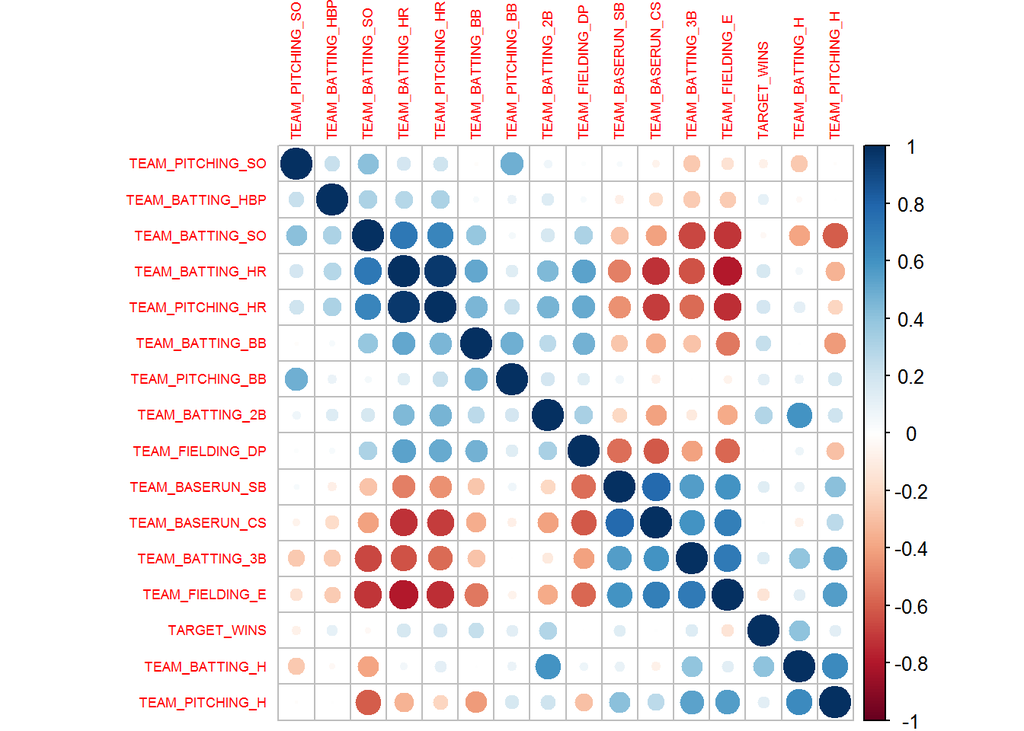

We will remove dataB.TEAM_BATTING_HR and dataB.TEAM_FIELDING_E as they are very highly corelated to other predictors

```
##
## Call:
## lm(formula = TARGET_WINS ~ . - TEAM_BATTING_HR - TEAM_FIELDING_E,
##     data = datanorm)
##
## Residuals:
##     Min      1Q  Median      3Q     Max
## -3.7895 -0.5299  0.0261  0.5535  3.3921
##
## Coefficients:
##                    Estimate Std. Error t value Pr(>|t|)
## (Intercept)       2.651e-11  1.731e-02   0.000 1.000000
## TEAM_BATTING_H    4.762e-01  3.627e-02  13.131  < 2e-16 ***
## TEAM_BATTING_2B   3.022e-02  2.748e-02   1.100 0.271653
## TEAM_BATTING_3B   4.726e-02  2.952e-02   1.601 0.109605
## TEAM_BATTING_BB   2.787e-01  3.513e-02   7.932 3.37e-15 ***
## TEAM_BATTING_SO  -3.249e-01  4.280e-02  -7.592 4.58e-14 ***
## TEAM_BASERUN_SB   2.010e-01  3.179e-02   6.322 3.10e-10 ***
## TEAM_BASERUN_CS   1.215e-01  3.676e-02   3.305 0.000963 ***
## TEAM_BATTING_HBP  1.329e-01  1.921e-02   6.919 5.91e-12 ***
## TEAM_PITCHING_H  -3.424e-01  3.918e-02  -8.740  < 2e-16 ***
## TEAM_PITCHING_HR  3.572e-01  3.676e-02   9.715  < 2e-16 ***
## TEAM_PITCHING_BB -1.394e-01  3.369e-02  -4.137 3.65e-05 ***
## TEAM_PITCHING_SO  1.653e-01  3.017e-02   5.480 4.74e-08 ***
## TEAM_FIELDING_DP -1.337e-01  2.415e-02  -5.536 3.44e-08 ***
## ---
## Signif. codes:  0 '***' 0.001 '**' 0.01 '*' 0.05 '.' 0.1 ' ' 1
##
## Residual standard error: 0.8258 on 2262 degrees of freedom
## Multiple R-squared:  0.3219, Adjusted R-squared:  0.318
## F-statistic:  82.6 on 13 and 2262 DF,  p-value: < 2.2e-16
```

It appears that removing highly correlated predictors also does not help our model.

## 5. Select Model

Next we will review residual plot and qqplot of the model. We want to make sure the residuals are random and the variance is consatant.

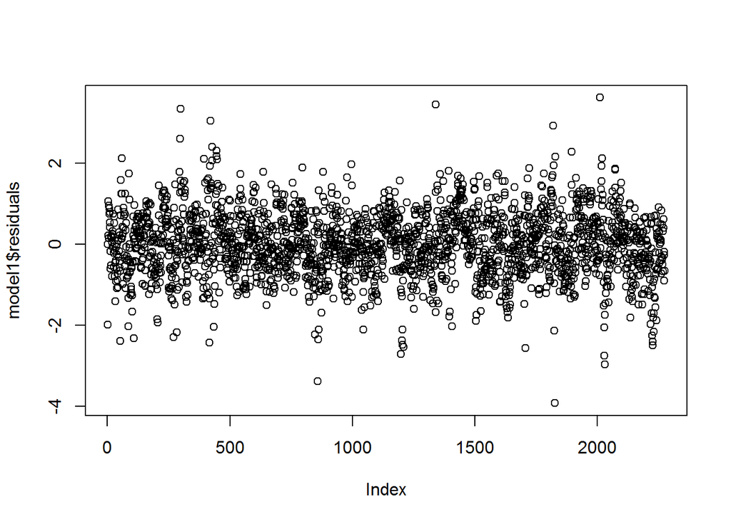

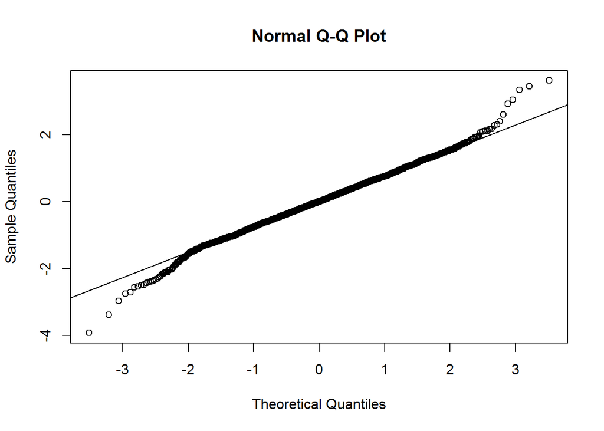

[output not shown]